# Veri Görselleştirme

#### 1.3.2.2 Çizgi grafiği (Line graph)

İki değişkenden biri zamanı temsil ettiğinde, bir çizgi grafiği ile ilişkiyi göstermenin etkili bir yöntemidir. Örneğin, aşağıdaki kod, Amerika Birleşik Devletleri’nde 1952 ile 2007 yılları arasında zaman (*year*) ve yaşam beklentisi (*lifeExp*) arasındaki ilişkiyi gösterir. Veriler, gapminder veri kümesinden alındı.

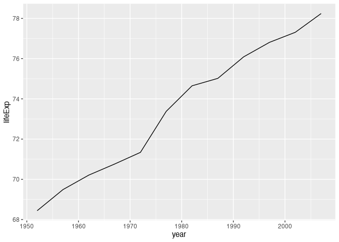

```r
data(gapminder, package="gapminder")

# Select US cases
library(dplyr)
plotdata <- filter(gapminder,
                   country == "United States")

# simple line plot
ggplot(plotdata,
       aes(x = year,
           y = lifeExp)) +
  geom_line()
```

Yukarıdaki grafikte tek tek değerleri okumak zordur. Bir sonraki olay örgüsünde pointleri de ekleyeceğiz.

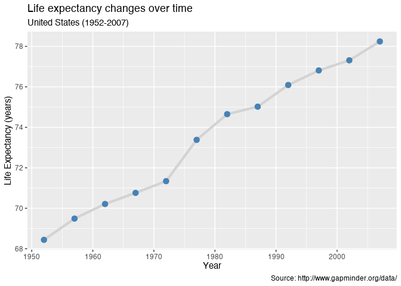

```r
# line plot with points
# and improved labeling
ggplot(plotdata,
       aes(x = year,
           y = lifeExp)) +
  geom_line(size = 1.5,
            color = "lightgrey") +
  geom_point(size = 3,
             color = "steelblue") +
  labs(y = "Life Expectancy (years)",
       x = "Year",
       title = "Life expectancy changes over time",
       subtitle = "United States (1952-2007)",
       caption = "Source: http://www.gapminder.org/data/")
```

Zamana bağlı veriler, Zaman serileri altında daha ayrıntılı olarak ele alınmıştır.

Bir **zaman serisi**, birbirini takip eden zaman noktalarında elde edilen nicel değerler kümesidir. Zaman noktaları arasındaki aralıklar (örneğin, saatler, günler, haftalar, aylar veya yıllar) genellikle eşittir.

`ggplot2` paketiyle birlikte gelen Ekonomi zaman serisini düşünün. Ocak 1967’den Ocak 2015’e kadar toplanan ABD aylık ekonomik verilerini içerir. Kişisel tasarruf oranını (*psavert*) planlayalım. Bunu basit bir çizgi grafiği ile yapabiliriz.

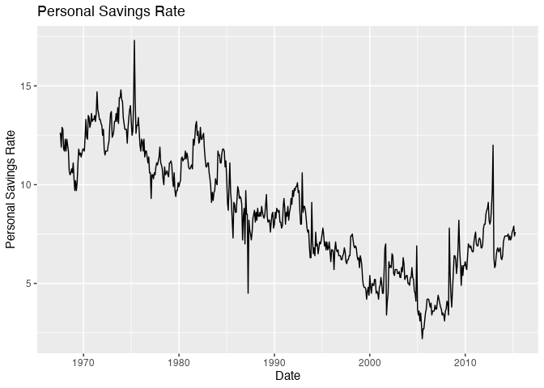

```r
data(economics, package="ggplot2")

ggplot(economics, aes(x = date, y = psavert)) +
  geom_line() +
  labs(title = "Personal Savings Rate",
       x = "Date",
       y = "Personal Savings Rate")
```

`scale_x_date` işlevi tarihleri yeniden biçimlendirmek için kullanılabilir. Ek olarak, zaman serisi çizgisine kırık kırmızı bir renk verilir ve daha kalın hale getirilir, bir trend çizgisi (loess) ve başlıklar eklenir ve tema basitleştirilir.

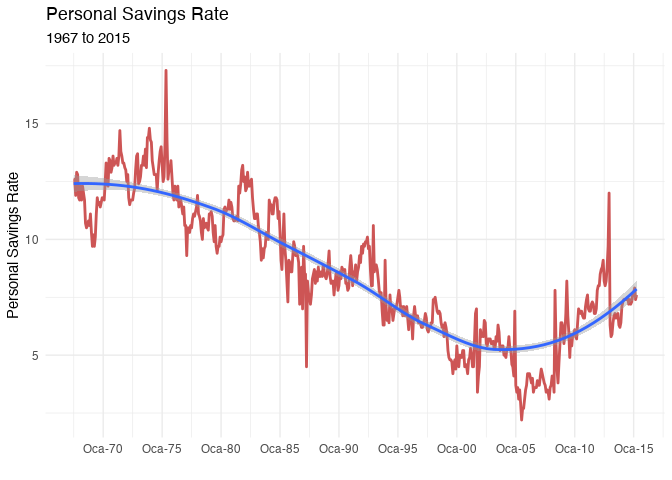

```r
library(ggplot2)
library(scales)
ggplot(economics, aes(x = date, y = psavert)) +
  geom_line(color = "indianred3",
            size=1 ) +
  geom_smooth() +
  scale_x_date(date_breaks = '5 years',
               labels = date_format("%b-%y")) +
  labs(title = "Personal Savings Rate",
       subtitle = "1967 to 2015",
       x = "",
       y = "Personal Savings Rate") +
  theme_minimal()
```

[figure not shown]

```r
# multivariate time series

# one time install
# install.packages("quantmod")

library(quantmod)
library(dplyr)

# get apple (AAPL) closing prices
apple <- getSymbols("AAPL",
                    return.class = "data.frame",
                    from="2018-01-01")

apple <- AAPL %>%
  mutate(Date = as.Date(row.names(.))) %>%
  dplyr::select(Date, AAPL.Close) %>%
  rename(Close = AAPL.Close) %>%
  mutate(Company = "Apple")



# get facebook (FB) closing prices
facebook <- getSymbols("FB",
                        return.class = "data.frame",
                       from="2018-01-01")

facebook <- FB %>%
  mutate(Date = as.Date(row.names(.))) %>%
  dplyr::select(Date, FB.Close) %>%
  rename(Close = FB.Close) %>%
  mutate(Company = "Facebook")

# combine data for both companies
mseries <- rbind(apple, facebook)

# plot data
library(ggplot2)
ggplot(mseries,
       aes(x=Date, y= Close, color=Company)) +
  geom_line(size=1) +
  scale_x_date(date_breaks = '1 month',
               labels = scales::date_format("%b")) +
  labs(title = "NASDAQ Closing Prices",
       subtitle = "Jan - Aug 2018",
       caption = "source: Yahoo Finance",
       y = "Closing Price") +
  theme_minimal() +
  scale_color_brewer(palette = "Dark2")
```

### 1.3.2. Kategorik vs Kantitatif

Kategorik bir değişken ile nicel bir değişken arasındaki ilişkiyi çizerken, çok sayıda grafik türü mevcuttur. Bunlar, özet istatistikleri kullanan çubuk grafikleri, gruplandırılmış Kernel yoğunluğu grafikleri (grouped kernel density plots), yan yana kutu grafikleri (side-by-side box plots), yan yana violin grafikleri (side-by-side violin plots), ortalama / sem (mean/sem plots) grafikleri, sırt grafikleri (ridgeline plots) ve Cleveland grafikleridir.

#### 1.3.2.1. Çubuk grafik (özet istatistiklerde)

Önceki bölümlerde, tek bir değişken veya iki değişken için kategoriye göre vaka sayısını görüntülemek için çubuk grafikler kullanıldı. Bir kategorik değişkenin her seviyesi için nicel bir değişken üzerindeki diğer özet istatistikleri (ör. ortalamalar veya medyanlar) görüntülemek için de çubuk grafikleri kullanabilirsiniz.

Örneğin, aşağıdaki grafik, bir üniversite profesörü örnekleminin akademik sıralarına göre ortalama maaşını göstermektedir.

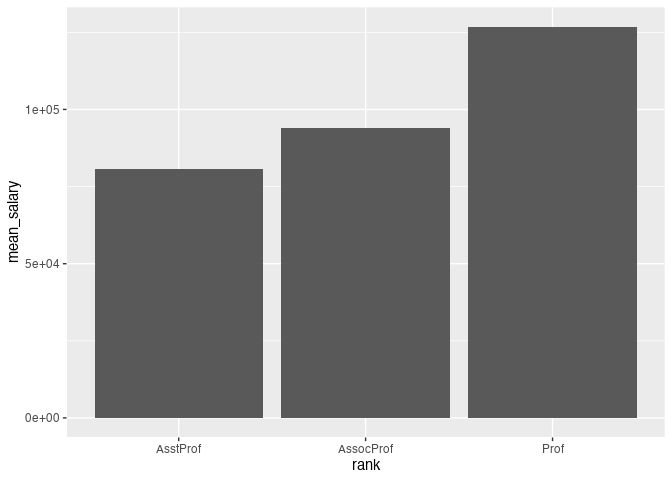

```r
data(Salaries, package="carData")

# calculate mean salary for each rank
library(dplyr)
plotdata <- Salaries %>%
  group_by(rank) %>%
  summarize(mean_salary = mean(salary))

# plot mean salaries
ggplot(plotdata,
       aes(x = rank,
           y = mean_salary)) +
  geom_bar(stat = "identity")
```

Bazı seçeneklerle daha çekici hale getirebiliriz.

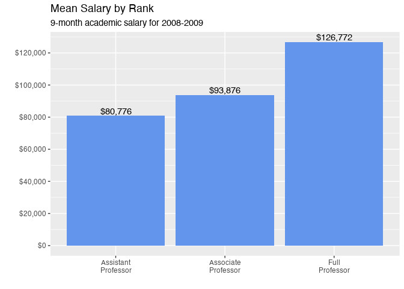

```r
# plot mean salaries in a more attractive fashion
library(scales)
ggplot(plotdata,
       aes(x = factor(rank,
                      labels = c("Assistant\nProfessor",
                                 "Associate\nProfessor",
                                 "Full\nProfessor")),
                      y = mean_salary)) +
  geom_bar(stat = "identity",
           fill = "cornflowerblue") +
  geom_text(aes(label = dollar(mean_salary)),
            vjust = -0.25) +
  scale_y_continuous(breaks = seq(0, 130000, 20000),
                     label = dollar) +
  labs(title = "Mean Salary by Rank",
       subtitle = "9-month academic salary for 2008-2009",
       x = "",
       y = "")
```

#### 1.3.2.2. Gruplandırılmış Kernel yoğunluğu grafikleri

Tek bir grafikte Kernel yoğunluğu çizimlerini üst üste bindirerek sayısal bir değişken üzerindeki grupları karşılaştırabiliriz.

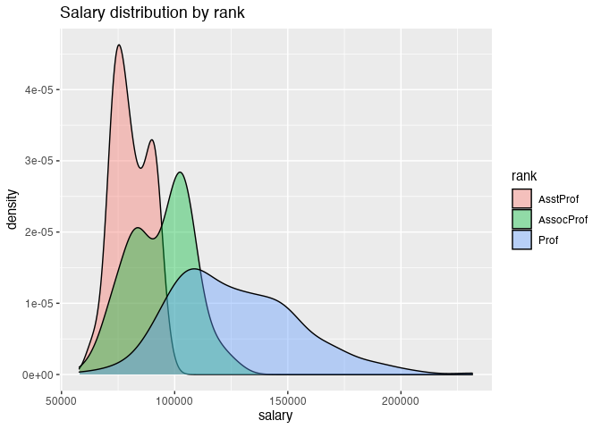

```r
# plot the distribution of salaries
# by rank using kernel density plots
ggplot(Salaries,
       aes(x = salary,
           fill = rank)) +
  geom_density(alpha = 0.4) +
  labs(title = "Salary distribution by rank")
```

#### 1.3.2.3. Kutu grafikleri

Yan yana kutu grafikleri, sayısal bir değişken üzerindeki grupları (yani kategorik bir değişkenin seviyelerini) karşılaştırmak için çok kullanışlıdır.

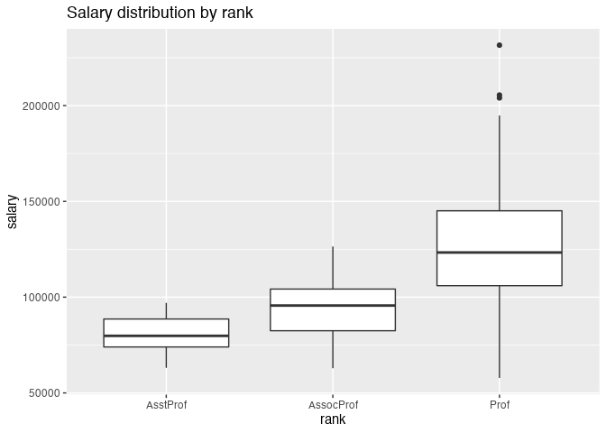

```r
# plot the distribution of salaries by rank using boxplots
ggplot(Salaries,
       aes(x = rank,
           y = salary)) +
  geom_boxplot() +
  labs(title = "Salary distribution by rank")
```

Çentikli kutu grafikleri, grupların farklı olup olmadığını görselleştirmek için yaklaşık bir yöntem sağlar. Resmi bir test olmasa da, iki kutu grafiğin çentikleri çakışmazsa, iki grubun medyanlarının farklı olduğuna dair güçlü kanıtlar (% 95 güven) vardır.

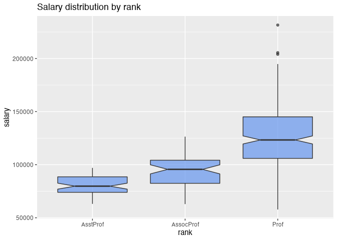

```r
# plot the distribution of salaries by rank using boxplots
ggplot(Salaries, aes(x = rank,
                     y = salary)) +
  geom_boxplot(notch = TRUE,
               fill = "cornflowerblue",
               alpha = .7) +
  labs(title = "Salary distribution by rank")
```

#### 1.3.2.4. Ridgeline Grafiği

Ridgeline grafiği (joyplot olarak da adlandırılır), birkaç grup için nicel bir değişkenin dağılımını gösterir. Dikey fasetli çekirdek yoğunluğu grafiklerine benzerler, ancak daha az yer kaplarlar. Ridgeline grafikleri, `ggridges` paketiyle oluşturulur.

Yakıt ekonomisi veri kümesini kullanarak, araba sınıfına göre galon başına şehir sürüş mil dağılımının grafiğini çizelim.

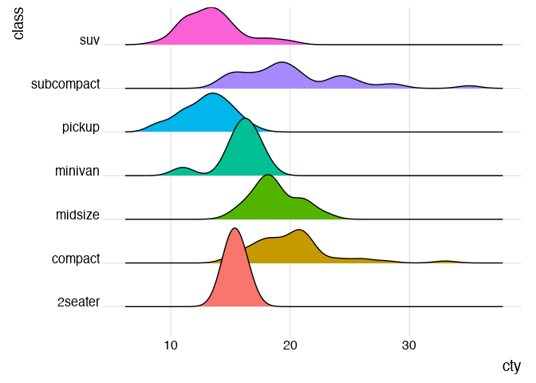

```r
# create ridgeline graph
library(ggplot2)
library(ggridges)

ggplot(mpg,
       aes(x = cty,
           y = class,
           fill = class)) +
  geom_density_ridges() +
  theme_ridges() +
  labs("Highway mileage by auto class") +
  theme(legend.position = "none")
```

#### 1.3.2.5. Cleveland Nokta Grafikleri

Cleveland grafikleri, çok sayıda grup için sayısal bir istatistiği karşılaştırmak istediğinizde kullanışlıdır. Örneğin, gapminder veri kümesini kullanarak Asya ülkesi için 2007 yaşam beklentisini karşılaştırmak istediğinizi varsayalım.

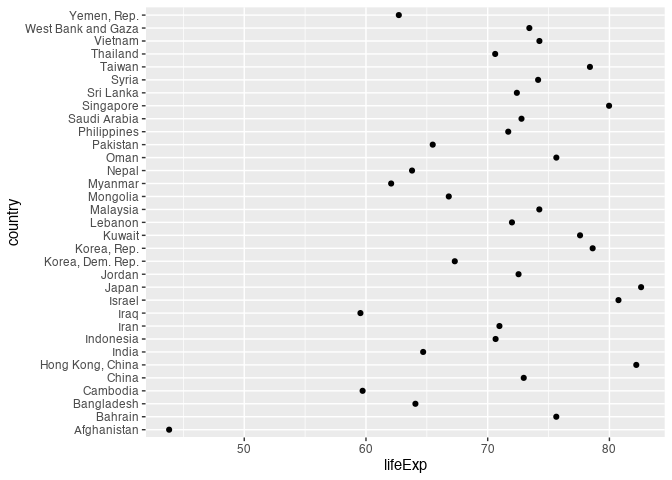

```r
data(gapminder, package="gapminder")

# subset Asian countries in 2007
library(dplyr)
plotdata <- gapminder %>%
  filter(continent == "Asia" &
         year == 2007)

# basic Cleveland plot of life expectancy by country
ggplot(plotdata,
       aes(x= lifeExp, y = country)) +
  geom_point()
```

*y-ekseni* sıralanırsa karşılaştırmalar genellikle daha kolaydır.

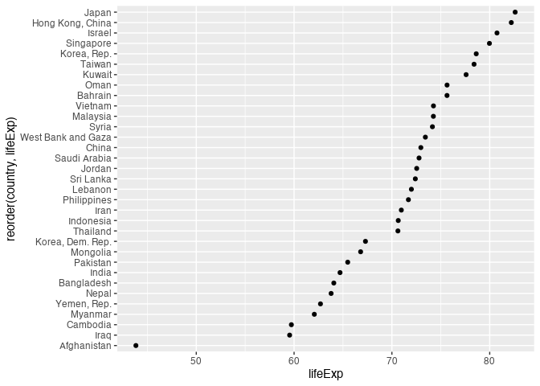

```r
# Sorted Cleveland plot
ggplot(plotdata,
       aes(x=lifeExp,
           y=reorder(country, lifeExp))) +
  geom_point()
```

Son olarak, grafiği daha çekici hale getirmek için bazı fonksiyonları kullanabiliriz.

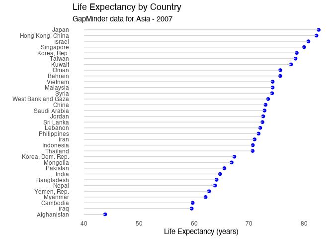

```r
# Fancy Cleveland plot
ggplot(plotdata,
       aes(x=lifeExp,
           y=reorder(country, lifeExp))) +
  geom_point(color="blue",
             size = 2) +
  geom_segment(aes(x = 40,
               xend = lifeExp,
               y = reorder(country, lifeExp),
               yend = reorder(country, lifeExp)),
               color = "lightgrey") +
  labs (x = "Life Expectancy (years)",
        y = "",
        title = "Life Expectancy by Country",
        subtitle = "GapMinder data for Asia - 2007") +
  theme_minimal() +
  theme(panel.grid.major = element_blank(),
        panel.grid.minor = element_blank())
```